# Analysis of exposures with a neutral discourse context (no canonical markedness feature during generation)

This notebook analyzes the generalization patterns of novel dative-verb learners based on the factors of exposure contexts which situate the novel verb in a neutral discourse context where only the agent is given. For example:

```
DO: it was a nice day . mommy [verbed] me a ball.
PP: it was a nice day . mommy [verbed] a ball to me .
```

## Loading Data (code hidden)

```
 Found 500 records...
 Found 1000 records...
 Found 1500 records...
 Found 1620 records...
 Imported 1620 records. Simplifying...

 Found 255 records...
 Imported 255 records. Simplifying...
```

## Cross Dative Generalization

Investigating alternate-form generalization patterns of the learner when it is exposed to the double object dative vs. prepositional object dative.

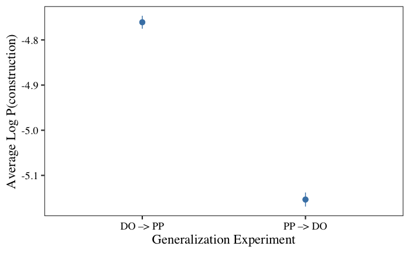

## Conwell’s “me” finding (2019):

Pronominal recipients enable DO comprehension in children, so if we were to believe that comprehension is a precondition to generalization, then pronominal recipients should also encourage generalization:

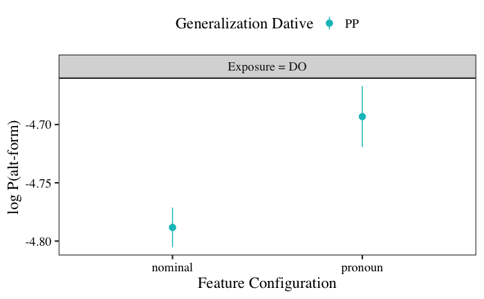

## Replicating Arunachalam (2017):

Only looking at definite themes and recipients:

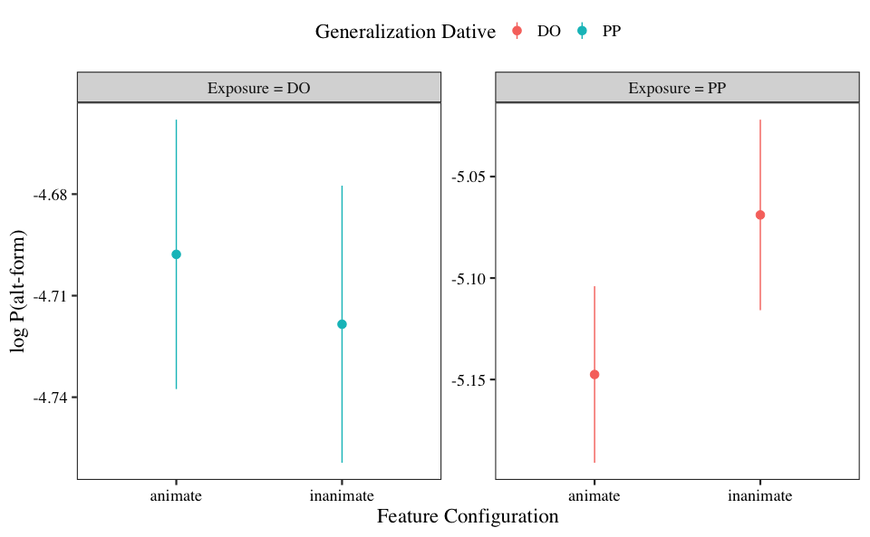

## Interaction terms

The design of interaction terms is a bit tricky. Due to our design, the pronominality might interact with the animacy of a given argument, but animacy and pronominality might also interact across arguments – e.g., if theme is inanimate then LMs might prefer animate recipients (if they are sensitive to the semantics of the dative construction – caused possession/motion). This means we should include the following interaction terms:

```
- theme_animacy * theme_pronominality
- recipient_animacy * recipient_pronominality
- theme_animacy * recipient_animacy
- theme_pronominality * recipient pronominality
```

## DO –> PP analysis

```r
do_pp <- coded_results %>%
  filter(adaptation_dative == "do", generalization_dative == "pp")

# interactions between theme-animacy and recipient animacy; theme-pronominality and recipient-pronominality

fit_tara_tprp_interaction_dopp <- lmer(best ~
                                    theme_animacy * theme_pronominality +
                                    recipient_animacy * recipient_pronominality +
                                    theme_animacy * recipient_animacy +
                                    theme_pronominality * recipient_pronominality +
                                    theme_definiteness + recipient_definiteness +
                                    theme_length + recipient_length +
                                    (1|model) + (1|item_id), data = do_pp)

summary(fit_tara_tprp_interaction_dopp, correlation = FALSE)
```

```
Linear mixed model fit by REML. t-tests use Satterthwaite's method ['lmerModLmerTest']
Formula: best ~ theme_animacy * theme_pronominality + recipient_animacy *
    recipient_pronominality + theme_animacy * recipient_animacy +
    theme_pronominality * recipient_pronominality + theme_definiteness +
    recipient_definiteness + theme_length + recipient_length +      (1 | model) + (1 | item_id)
   Data: do_pp

REML criterion at convergence: 14800.4

Scaled residuals:
    Min      1Q  Median      3Q     Max
-4.8857 -0.6466  0.0993  0.7123  2.3765

Random effects:
 Groups   Name        Variance Std.Dev.
 item_id  (Intercept) 0.04662  0.2159
 model    (Intercept) 0.04589  0.2142
 Residual             0.32910  0.5737
Number of obs: 8100, groups:  item_id, 810; model, 10

Fixed effects:
                                              Estimate Std. Error         df t value Pr(>|t|)
(Intercept)                                  -4.792719   0.069659   9.886065 -68.802 1.38e-14 ***
theme_animacy                                -0.048023   0.022186 796.999862  -2.165 0.030720 *
theme_pronominality                          -0.065793   0.030257 796.999862  -2.175 0.029960 *
recipient_animacy                             0.078700   0.022186 796.999861   3.547 0.000412 ***
recipient_pronominality                       0.071668   0.030257 796.999861   2.369 0.018090 *
theme_definiteness                           -0.006222   0.019930 796.999862  -0.312 0.754996
recipient_definiteness                        0.097075   0.019930 796.999862   4.871 1.34e-06 ***
theme_length                                  0.054701   0.023500 796.999862   2.328 0.020179 *
recipient_length                              0.136473   0.023500 796.999861   5.807 9.17e-09 ***
theme_animacy:theme_pronominality             0.016945   0.044373 796.999862   0.382 0.702646
recipient_animacy:recipient_pronominality     0.121864   0.044373 796.999861   2.746 0.006162 **
theme_animacy:recipient_animacy              -0.148368   0.039754 796.999862  -3.732 0.000203 ***
theme_pronominality:recipient_pronominality   0.242187   0.055764 796.999861   4.343 1.59e-05 ***
---
Signif. codes:  0 ‘***’ 0.001 ‘**’ 0.01 ‘*’ 0.05 ‘.’ 0.1 ‘ ’ 1
```

## PP –> DO Analysis

```r
pp_do <- coded_results %>%
  filter(adaptation_dative == "pp", generalization_dative == "do")

fit_tara_tprp_interaction_ppdo <- lmer(best ~
                                    theme_animacy * theme_pronominality +
                                    recipient_animacy * recipient_pronominality +
                                    theme_animacy * recipient_animacy +
                                    theme_pronominality * recipient_pronominality +
                                    theme_definiteness + recipient_definiteness +
                                    theme_length  + recipient_length +
                                    (1|model) + (1|item_id), data = pp_do)

summary(fit_tara_tprp_interaction_ppdo, correlation = FALSE)
```

```
Linear mixed model fit by REML. t-tests use Satterthwaite's method ['lmerModLmerTest']
Formula: best ~ theme_animacy * theme_pronominality + recipient_animacy *
    recipient_pronominality + theme_animacy * recipient_animacy +
    theme_pronominality * recipient_pronominality + theme_definiteness +
    recipient_definiteness + theme_length + recipient_length +      (1 | model) + (1 | item_id)
   Data: pp_do

REML criterion at convergence: 16060.9

Scaled residuals:
    Min      1Q  Median      3Q     Max
-5.0048 -0.6257  0.1082  0.7194  2.7453

Random effects:
 Groups   Name        Variance Std.Dev.
 item_id  (Intercept) 0.04982  0.2232
 model    (Intercept) 0.04789  0.2188
 Residual             0.38673  0.6219
Number of obs: 8100, groups:  item_id, 810; model, 10

Fixed effects:
                                             Estimate Std. Error        df t value Pr(>|t|)
(Intercept)                                  -5.18375    0.07129   9.93518 -72.712 7.03e-15 ***
theme_animacy                                -0.07271    0.02340 797.00013  -3.107 0.001959 **
theme_pronominality                           0.13473    0.03192 797.00013   4.221 2.71e-05 ***
recipient_animacy                             0.03951    0.02340 797.00013   1.688 0.091779 .
recipient_pronominality                       0.04648    0.03192 797.00013   1.456 0.145696
theme_definiteness                            0.02445    0.02102 797.00013   1.163 0.245282
recipient_definiteness                        0.03202    0.02102 797.00013   1.523 0.128171
theme_length                                  0.27659    0.02479 797.00013  11.157  < 2e-16 ***
recipient_length                              0.18380    0.02479 797.00013   7.414 3.13e-13 ***
theme_animacy:theme_pronominality            -0.19546    0.04681 797.00013  -4.176 3.30e-05 ***
recipient_animacy:recipient_pronominality    -0.02047    0.04681 797.00013  -0.437 0.662049
theme_animacy:recipient_animacy              -0.06901    0.04194 797.00013  -1.646 0.100252
theme_pronominality:recipient_pronominality   0.22146    0.05882 797.00013   3.765 0.000179 ***
---
Signif. codes:  0 ‘***’ 0.001 ‘**’ 0.01 ‘*’ 0.05 ‘.’ 0.1 ‘ ’ 1
```

## Attempt at displaying DO -> PP and PP -> DO in same table:

```r
tidy(fit_tara_tprp_interaction_dopp) %>%
  filter(effect == "fixed") %>%
  select(term, do_pp_estimate = estimate, do_pp_pval = p.value) %>%
  inner_join(
    tidy(fit_tara_tprp_interaction_ppdo) %>%
      filter(effect == "fixed") %>%
      select(term, pp_do_estimate = estimate, pp_do_pval = p.value)
  ) %>%
  mutate(
    # do_pp_estimate = format(do_pp_estimate , scientific=TRUE),
    # pp_do_estimate = format(pp_do_estimate, scientific=TRUE),
    do_pp_estimate = round(do_pp_estimate, 4),
    pp_do_estimate = round(pp_do_estimate, 4),
    do_pp_signif = case_when(
      do_pp_pval < 0.05 ~ "**",
      TRUE ~ as.character(round(do_pp_pval, 4))
    ),
    pp_do_signif = case_when(
      pp_do_pval < 0.05 ~ "**",
      TRUE ~ as.character(round(pp_do_pval, 4))
    )
  ) %>%
  select(term, do_pp_estimate, do_pp_signif, pp_do_estimate, pp_do_signif) %>%
  DT::datatable(options = list(pageLength = 14))
```

|  | term | do_pp_estimate | do_pp_signif | pp_do_estimate | pp_do_signif |
| --- | --- | --- | --- | --- | --- |
| 1 | (Intercept) | -4.7927 | ** | -5.1837 | ** |
| 2 | theme_animacy | -0.048 | ** | -0.0727 | ** |
| 3 | theme_pronominality | -0.0658 | ** | 0.1347 | ** |
| 4 | recipient_animacy | 0.0787 | ** | 0.0395 | 0.0918 |
| 5 | recipient_pronominality | 0.0717 | ** | 0.0465 | 0.1457 |
| 6 | theme_definiteness | -0.0062 | 0.755 | 0.0244 | 0.2453 |
| 7 | recipient_definiteness | 0.0971 | ** | 0.032 | 0.1282 |
| 8 | theme_length | 0.0547 | ** | 0.2766 | ** |
| 9 | recipient_length | 0.1365 | ** | 0.1838 | ** |
| 10 | theme_animacy:theme_pronominality | 0.0169 | 0.7026 | -0.1955 | ** |

[output cut: 3 more lines]

## LMER for Arunachalam (2017)

```r
do_pp_sudha <- sudha %>%
  filter(adaptation_dative == "do", generalization_dative == "pp")

# interactions between theme-animacy and recipient animacy; theme-pronominality and recipient-pronominality

fit_tara_tprp_interaction_dopp_sudha <- lmer(best ~
                                    theme_animacy * theme_pronominality +
                                    recipient_animacy * recipient_pronominality +
                                    theme_animacy * recipient_animacy +
                                    theme_pronominality * recipient_pronominality +
                                    theme_length  + recipient_length +
                                    (1|model) + (1|item_id), data = do_pp_sudha)

summary(fit_tara_tprp_interaction_dopp_sudha, correlation = FALSE)
```

```
Linear mixed model fit by REML. t-tests use Satterthwaite's method ['lmerModLmerTest']
Formula: best ~ theme_animacy * theme_pronominality + recipient_animacy *
    recipient_pronominality + theme_animacy * recipient_animacy +
    theme_pronominality * recipient_pronominality + theme_length +
    recipient_length + (1 | model) + (1 | item_id)
   Data: do_pp_sudha

REML criterion at convergence: 3840

Scaled residuals:
    Min      1Q  Median      3Q     Max
-4.8553 -0.6399  0.1025  0.7088  2.3405

Random effects:
 Groups   Name        Variance Std.Dev.
 item_id  (Intercept) 0.02880  0.1697
 model    (Intercept) 0.06334  0.2517
 Residual             0.33106  0.5754
Number of obs: 2100, groups:  item_id, 210; model, 10

Fixed effects:
                                             Estimate Std. Error        df t value Pr(>|t|)
(Intercept)                                  -4.70439    0.08357  10.41185 -56.290 2.80e-14 ***
theme_animacy                                 0.03801    0.03767 198.99871   1.009  0.31415
theme_pronominality                          -0.06901    0.04659 198.99871  -1.481  0.14016
recipient_animacy                             0.09448    0.03767 198.99871   2.508  0.01293 *
recipient_pronominality                       0.26709    0.04659 198.99871   5.732 3.63e-08 ***
theme_length                                  0.03377    0.04147 198.99871   0.814  0.41637
recipient_length                              0.12554    0.04147 198.99871   3.027  0.00279 **
theme_animacy:theme_pronominality             0.12881    0.07533 198.99871   1.710  0.08885 .
recipient_animacy:recipient_pronominality     0.09869    0.07533 198.99871   1.310  0.19168
theme_animacy:recipient_animacy              -0.15530    0.06939 198.99871  -2.238  0.02633 *
theme_pronominality:recipient_pronominality   0.17217    0.08345 198.99871   2.063  0.04041 *
---
Signif. codes:  0 ‘***’ 0.001 ‘**’ 0.01 ‘*’ 0.05 ‘.’ 0.1 ‘ ’ 1
```

```r
pp_do_sudha <- sudha %>%
  filter(adaptation_dative == "pp", generalization_dative == "do")

# interactions between theme-animacy and recipient animacy; theme-pronominality and recipient-pronominality

fit_tara_tprp_interaction_ppdo_sudha <- lmer(best ~
                                    theme_animacy * theme_pronominality +
                                    recipient_animacy * recipient_pronominality +
                                    theme_animacy * recipient_animacy +
                                    theme_pronominality * recipient_pronominality +
                                    theme_length  + recipient_length +
                                    (1|model) + (1|item_id), data = pp_do_sudha)

summary(fit_tara_tprp_interaction_ppdo_sudha, correlation = FALSE)
```

```
Linear mixed model fit by REML. t-tests use Satterthwaite's method ['lmerModLmerTest']
Formula: best ~ theme_animacy * theme_pronominality + recipient_animacy *
    recipient_pronominality + theme_animacy * recipient_animacy +
    theme_pronominality * recipient_pronominality + theme_length +
    recipient_length + (1 | model) + (1 | item_id)
   Data: pp_do_sudha

REML criterion at convergence: 4147.6

Scaled residuals:
    Min      1Q  Median      3Q     Max
-4.4167 -0.6108  0.1000  0.7188  2.1781

Random effects:
 Groups   Name        Variance Std.Dev.
 item_id  (Intercept) 0.04514  0.2125
 model    (Intercept) 0.05772  0.2403
 Residual             0.37815  0.6149
Number of obs: 2100, groups:  item_id, 210; model, 10

Fixed effects:
                                             Estimate Std. Error        df t value Pr(>|t|)
(Intercept)                                  -5.11040    0.08151  11.20834 -62.698 1.26e-15 ***
theme_animacy                                -0.20706    0.04360 199.00149  -4.749 3.91e-06 ***
theme_pronominality                           0.29994    0.05394 199.00150   5.561 8.57e-08 ***
recipient_animacy                             0.05729    0.04360 199.00149   1.314  0.19038
recipient_pronominality                       0.14872    0.05394 199.00150   2.757  0.00637 **
theme_length                                  0.32800    0.04800 199.00149   6.833 9.93e-11 ***
recipient_length                              0.22036    0.04800 199.00149   4.590 7.83e-06 ***
theme_animacy:theme_pronominality            -0.52477    0.08720 199.00149  -6.018 8.37e-09 ***
recipient_animacy:recipient_pronominality    -0.13667    0.08720 199.00149  -1.567  0.11865
theme_animacy:recipient_animacy              -0.05713    0.08033 199.00149  -0.711  0.47776
theme_pronominality:recipient_pronominality   0.21758    0.09661 199.00149   2.252  0.02540 *
---
Signif. codes:  0 ‘***’ 0.001 ‘**’ 0.01 ‘*’ 0.05 ‘.’ 0.1 ‘ ’ 1
```

```r
tidy(fit_tara_tprp_interaction_dopp_sudha) %>%
  filter(effect == "fixed") %>%
  select(term, do_pp_estimate = estimate, do_pp_pval = p.value) %>%
  inner_join(
    tidy(fit_tara_tprp_interaction_ppdo_sudha) %>%
      filter(effect == "fixed") %>%
      select(term, pp_do_estimate = estimate, pp_do_pval = p.value)
  ) %>%
  mutate(
    # do_pp_estimate = format(do_pp_estimate , scientific=TRUE),
    # pp_do_estimate = format(pp_do_estimate, scientific=TRUE),
    do_pp_estimate = round(do_pp_estimate, 4),
    pp_do_estimate = round(pp_do_estimate, 4),
    do_pp_signif = case_when(
      do_pp_pval < 0.05 ~ "**",
      TRUE ~ as.character(round(do_pp_pval, 4))
    ),
    pp_do_signif = case_when(
      pp_do_pval < 0.05 ~ "**",
      TRUE ~ as.character(round(pp_do_pval, 4))
    )
  ) %>%
  select(term, do_pp_estimate, do_pp_signif, pp_do_estimate, pp_do_signif) %>%
  DT::datatable(options = list(pageLength = 14))
```

|  | term | do_pp_estimate | do_pp_signif | pp_do_estimate | pp_do_signif |
| --- | --- | --- | --- | --- | --- |
| 1 | (Intercept) | -4.7044 | ** | -5.1104 | ** |
| 2 | theme_animacy | 0.038 | 0.3142 | -0.2071 | ** |
| 3 | theme_pronominality | -0.069 | 0.1402 | 0.2999 | ** |
| 4 | recipient_animacy | 0.0945 | ** | 0.0573 | 0.1904 |
| 5 | recipient_pronominality | 0.2671 | ** | 0.1487 | ** |
| 6 | theme_length | 0.0338 | 0.4164 | 0.328 | ** |
| 7 | recipient_length | 0.1255 | ** | 0.2204 | ** |
| 8 | theme_animacy:theme_pronominality | 0.1288 | 0.0888 | -0.5248 | ** |
| 9 | recipient_animacy:recipient_pronominality | 0.0987 | 0.1917 | -0.1367 | 0.1186 |
| 10 | theme_animacy:recipient_animacy | -0.1553 | ** | -0.0571 | 0.4778 |

[output cut: 1 more lines]